# Cross Validation

2/21/2020

## Let’s go explore!

[figure not shown]

We are leaving the comfortable world of causal inference into the world of prediction. In math terms we are no longer thinking about the \(\hat\beta\) in \(\hat{y_i}=\beta_0 + \hat\beta_1*x_i+\epsilon_i\) but instead about \(\hat{y}\).

## What is Cross Validation (CV)?

CV is a resampling method used to compare how good different predictive models are at predicting an outcome \(\hat{y}\). “Good” is defined as finding the predictive model with the smallest MSE or MAE. We are briefly going to discuss three methods of CV:

- Validation Set Approach (Holdout Method)
- Leave One Out Cross Validation (LOOCV)
- K-folds cross validation

## Some quick definitions/concepts

[figure not shown]

- Training data: The “seen” data from our data set on which we train our predictive model
- Test data: The unseen data from our data set on which we apply our model from the training data to measure performance
- Bias/variance tradeoff: The tradeoff between underfitting the data (bias) vs overfitting the data (variance) with our predictive models

## Validation Set Approach (Holdout Method)

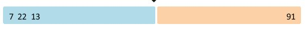

- Divide our dataset into a training set and a test set
- Train our model on the training set (blue)
- Test our models on the test set (orange? creamscicle?)

## Validation Set Approach (Holdout Method)

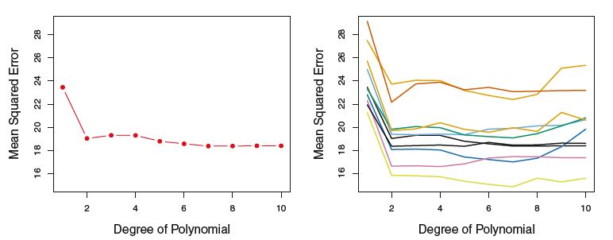

## Leave One Out Cross Validation (LOOCV)

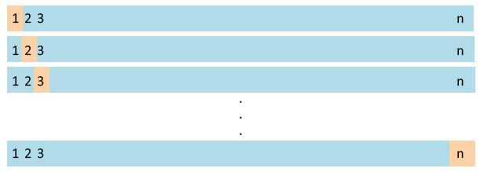

- Our training set is all the data except for one data point
- Our test (validation) set is the one remaining data point
- Every data point gets to be a test set up to n, then we average the MSE to measure model performance
- Less bias, but computationally expensive

## K-folds cross validation

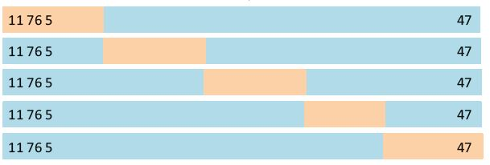

## Measuring Performance

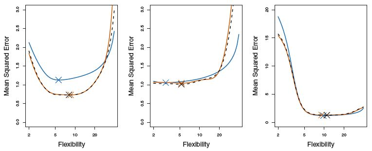

- Both types of cross validation methods perform similiarly.
- LOOCV is less biased than k folds method, but requires more computing power. Imagine if you sample has 100000 observations!
- K-folds is less computationally expensive and has less variance than LOOCV

## Resources

- Sit in on Ed’s machine learning class next year, it’s totally worth it.
- [Ed’s class notes](https://github.com/edrubin/EC524W20)
- [Introduction to Statistical Learning](http://faculty.marshall.usc.edu/gareth-james/ISL/) This book is free and does a good job of introducing machine learning.